# Project Draft

**Q6** 95% confidence interval of Admission Rate Average Based on Race:

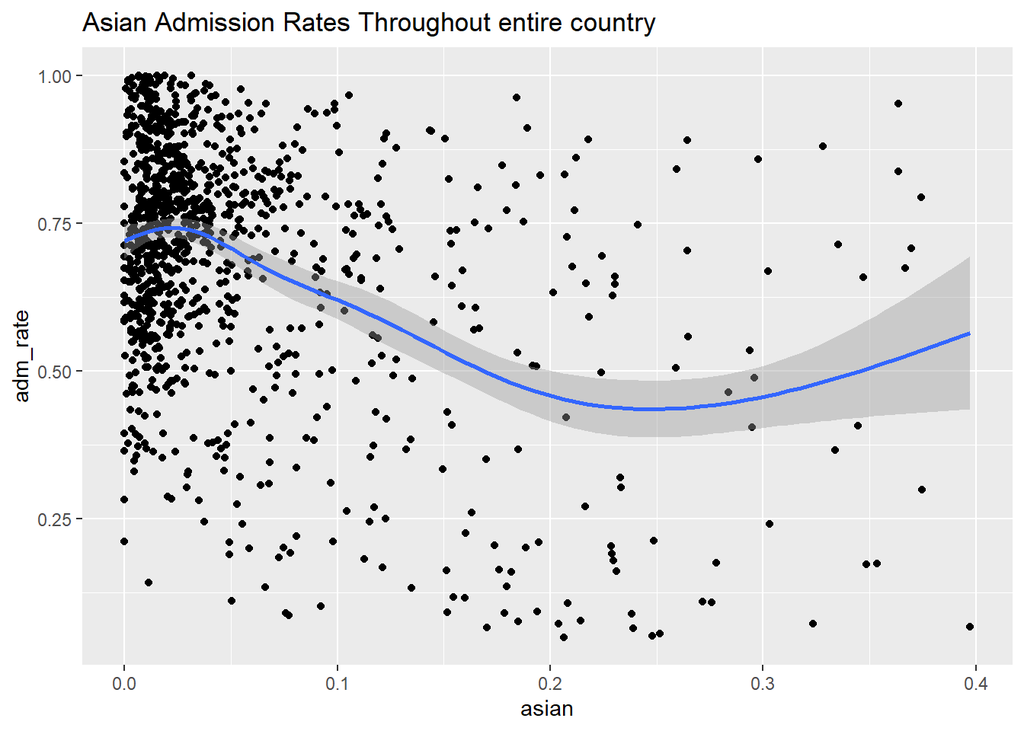

> This is a very simple scatter plot that shows the averge administrion rate of the asian race based on how many asians are in the colleges.

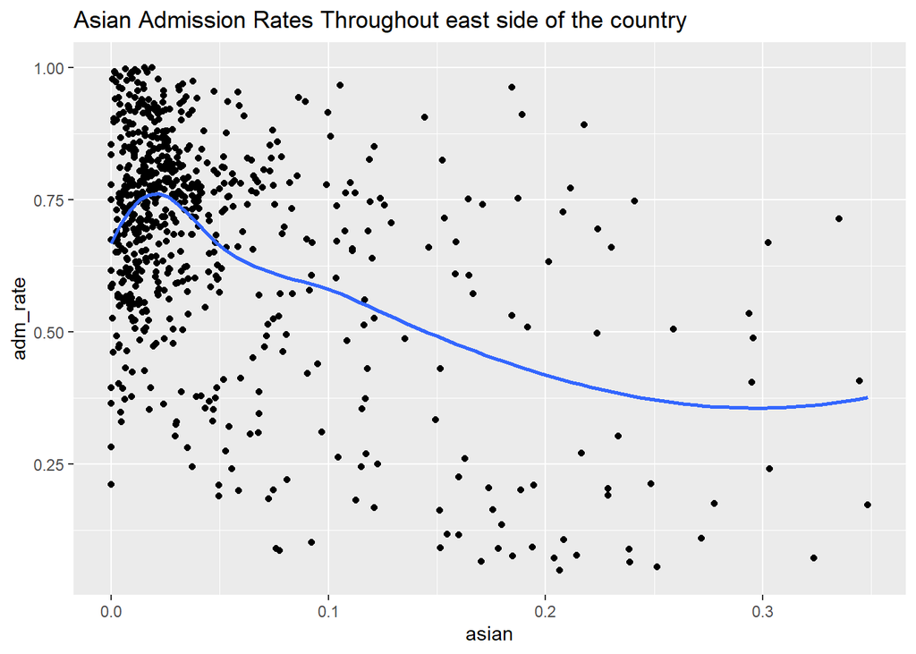

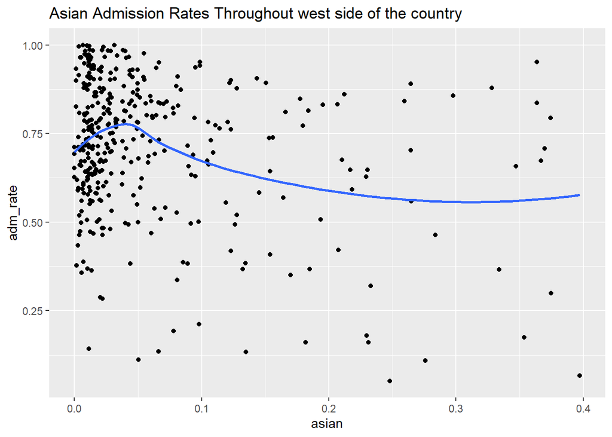

> This is a very simple scatter plot that shows the averge administrion rate of the asian race based on how many asians are in the colleges on the east coast and the west coast.

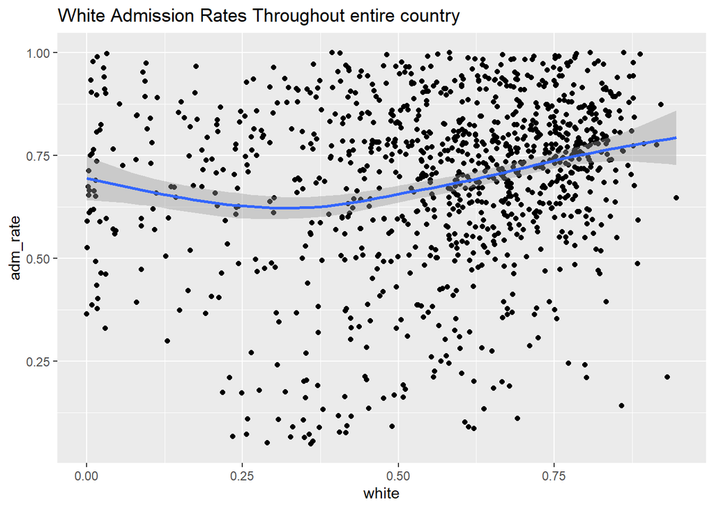

> This is a very simple scatter plot that shows the averge administrion rate of the white race based on how many white people are in the colleges.

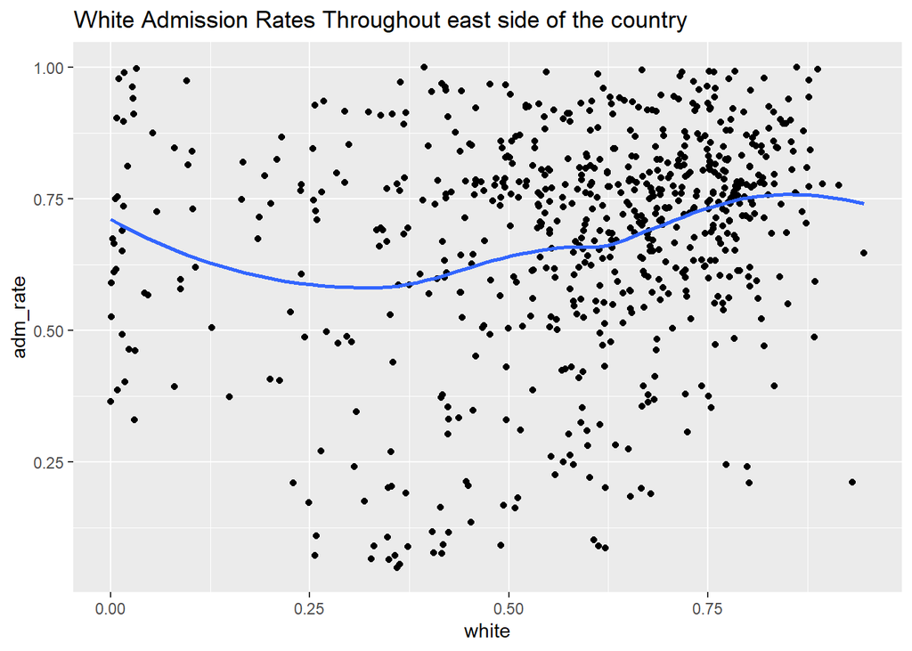